# APM_50441_EP - Machine Learning 2 - Lab 7: Machine learning at scale

This lab illustrates the seventh lecture (*At Scale*) on the flights of the United States in 2015. Its goals are:

- to read and store a large dataset efficiently (binary columnar formats, Parquet, partitions), and to use a sample when it is enough,
- to compare engines for the split/apply/combine computations on the full data, in memory (`dplyr`, `data.table`, `duckdb`) and directly on files (`arrow`, `duckdb`),
- to profile and optimize code, from the algorithm to the compiled language (`profvis`, `bench`, `Rcpp`),
- to parallelize a cross validation, and to measure when it pays off (`mirai`, `purrr::in_parallel()`),
- to serve a model with a REST API (`plumber2`) and a web application (`shiny` and `bslib`).

The optional *To go further* part, after the core, can be skipped at first: it covers Map/Reduce by hand, Spark, larger-than-memory computations, the memory hierarchy, pipelines, in-database scoring and the deployment of models.

We use `R` with the `tidyverse`. Most of the tools of this lab are not in the slides, which focus on the concepts: they are the current (2026) R implementations of these concepts.

**Working environment.** Colab is the simplest option: open the notebook version of this lab (`APM_50441_EP_Lab_7.ipynb`, *Open in Colab* link) with the R runtime, and run its first cell, which installs the packages. To work on your own computer, download the lab folder (the `.qmd` file and its files) or clone the course repository, open the `.qmd` file in RStudio or Positron (or VS Code with the R extension), and run it chunk by chunk or render it with Quarto. The packages are installed once with the script `PC/env/install_packages.R` (`source("install_packages.R")`, then `install_lab("lab7")`); Spark, only used in a *To go further* block, is installed separately with `install_spark()`. The data are read from the local files when they are present (otherwise they are downloaded).

**Use of AI.** AI assistants are allowed, but you must be able to explain every line you use, and you should answer the *predict before you run* questions before running the code: the suggested code may not be correct!

```r
library(tidyverse)
library(data.table)
library(arrow)
library(duckdb)
theme_set(theme_light())
if (!file.exists("data/flights_sample.csv.gz")) {
  dir.create("data", showWarnings = FALSE)
  for (f in c("flights_sample.csv.gz", "airlines.csv")) {
    download.file(paste0("https://raw.githubusercontent.com/APM-50441-EP/APM_50441_EP-2026-2027/main/PC7/data/", f), file.path("data", f), mode = "wb")
  }
}
for (f in c("cumsum.cc", "flights_api.R", "flights_app.R")) {  # the code files of the lab (Parts 3 and 5)
  if (!file.exists(f)) download.file(paste0("https://raw.githubusercontent.com/APM-50441-EP/APM_50441_EP-2026-2027/main/PC7/", f), f, mode = "wb")
}
airlines <- read_csv("data/airlines.csv", show_col_types = FALSE)
```

The full dataset ($5.8$ million flights, $1.4$ GB in memory) is too large for the computations of Parts 1, 3, 4 and 5 on some laptops: they use a random sample of $10\%$ of the flights ($582\,000$ flights). Part 2 uses the full data, stored as Parquet files ($138$ MB, downloaded once): it needs about $4$ GB of memory, which Colab and most laptops have.

## 1. Reading, storing and sampling

**Question** *Predict before you run:* which reader is the fastest? Read `data/flights_sample.csv.gz` with `readr::read_csv`, `data.table::fread` and `arrow::read_csv_arrow`, and compare their times with `bench::mark` ($3$ iterations, `check = FALSE`). What is the size of the data in memory (`lobstr::obj_size`)? Keep the data frame read by `readr` in `flights`: the rest of the lab uses it.

**Answer**

```r
col_types <- cols(ORIGIN_AIRPORT = "c", DESTINATION_AIRPORT = "c", SCHEDULED_DEPARTURE = "c", DEPARTURE_TIME = "c",
                  WHEELS_OFF = "c", WHEELS_ON = "c", SCHEDULED_ARRIVAL = "c", ARRIVAL_TIME = "c", CANCELLATION_REASON = "c")
reading <- bench::mark(
  readr = read_csv("data/flights_sample.csv.gz", col_types = col_types),
  data.table = fread("data/flights_sample.csv.gz"),
  arrow = read_csv_arrow("data/flights_sample.csv.gz"),
  iterations = 3, check = FALSE, filter_gc = FALSE)
reading |> transmute(reader = as.character(expression), min, median, mem_alloc)
```

```
# A tibble: 3 × 4
  reader          min   median mem_alloc
  <chr>      <bch:tm> <bch:tm> <bch:byt>
1 readr         3.28s    3.42s   200.4MB
2 data.table    1.08s    1.33s   173.2MB
3 arrow         1.21s    1.23s    64.8MB
```

```r
flights <- read_csv("data/flights_sample.csv.gz", col_types = col_types)
lobstr::obj_size(flights)
```

```
144.71 MB
```

**Conclusion** `data.table::fread` and `arrow::read_csv_arrow` read the compressed CSV file in about $1$ s, $2$ to $2.5$ times faster than `readr` (the timings vary a little from one run to another): they parse the file with several threads. Arrow also allocates much less memory during the reading ($65$ MB against $170$ to $200$ MB). In memory, the $582\,000$ flights take $145$ MB: the full dataset (ten times more rows) takes about $1.4$ GB (PC7, *Back-of-the-envelope estimates*). Decompression, parsing and disk access all contribute. These end-to-end timings do not measure their individual costs.

**Question** Write the flights as a Parquet dataset partitioned by `MONTH` (`arrow::write_dataset` in `data/flights_parquet`), and compare the size on disk with the CSV file. Then open it with `open_dataset`, and compute the mean arrival delay of the flights of December for each airline *without* loading the data in memory (`filter`, `group_by`, `summarise`, then `collect`). Compare the time with the same computation from the CSV file.

**Answer**

```r
write_dataset(flights, "data/flights_parquet", partitioning = "MONTH")
parquet_files <- list.files("data/flights_parquet", recursive = TRUE, full.names = TRUE)
c(`CSV (MB)` = file.size("data/flights_sample.csv.gz") / 1e6, `Parquet (MB)` = sum(file.size(parquet_files)) / 1e6,
  `Parquet files` = length(parquet_files))
```

```
     CSV (MB)  Parquet (MB) Parquet files
     22.71841      27.72192      12.00000
```

```r
flights_ds <- open_dataset("data/flights_parquet")
december <- function(data) data |> filter(MONTH == 12) |> group_by(AIRLINE) |>
  summarise(arrival_delay = mean(ARRIVAL_DELAY, na.rm = TRUE)) |> collect()
bench::mark(parquet = december(flights_ds),
            csv = december(read_csv("data/flights_sample.csv.gz", col_types = col_types)),
            iterations = 3, check = FALSE, filter_gc = FALSE) |> transmute(format = as.character(expression), min, median, mem_alloc)
```

```
# A tibble: 2 × 4
  format       min   median mem_alloc
  <chr>   <bch:tm> <bch:tm> <bch:byt>
1 parquet 148.18ms 157.22ms    6.82MB
2 csv        3.05s    3.25s  224.62MB
```

The *sampling trick* (lecture): for many questions, a random sample is enough, as the precision of an estimate depends on the size of the sample. Often, we do not need the full population to obtain a good enough estimate (PC7, *Reservoir sampling*).

**Question** Estimate the mean arrival delay of all the flights of the sample with random subsamples of $n = 100$, $1000$, $10\,000$ and $100\,000$ flights ($200$ subsamples each): compare the standard deviation of the estimates with $\sigma/\sqrt{n}$. Then compare a simple random subsample of $2004$ flights with a subsample *stratified* by month ($167$ flights each month, the monthly means being weighted by the proportions of the months).

**Answer**

```r
delays <- flights$ARRIVAL_DELAY[!is.na(flights$ARRIVAL_DELAY)]
set.seed(1)
precision <- map_dfr(c(100, 1000, 10000, 100000), function(n) {
  estimates <- replicate(200, mean(sample(delays, n)))
  tibble(n = n, `sd of the estimates` = sd(estimates), `sigma / sqrt(n)` = sd(delays) / sqrt(n),
         `finite population SE` = sd(delays) * sqrt((1 - n / length(delays)) / n))
})
precision
```

```
# A tibble: 4 × 4
       n `sd of the estimates` `sigma / sqrt(n)` `finite population SE`
   <dbl>                 <dbl>             <dbl>                  <dbl>
1    100                 3.85              3.92                   3.92
2   1000                 1.26              1.24                   1.24
3  10000                 0.424             0.392                  0.388
4 100000                 0.108             0.124                  0.112
```

```r
with_month <- flights |> filter(!is.na(ARRIVAL_DELAY)) |> select(MONTH, ARRIVAL_DELAY)
monthly_weights <- with_month |> count(MONTH) |> mutate(weight = n / sum(n))
stratified <- replicate(200, with_month |> group_by(MONTH) |> slice_sample(n = 167) |>
                          summarise(m = mean(ARRIVAL_DELAY)) |> left_join(monthly_weights, by = "MONTH") |>
                          summarise(sum(m * weight)) |> pull())
c(`simple random sampling` = sd(replicate(200, mean(sample(with_month$ARRIVAL_DELAY, 2004)))), stratified = sd(stratified))
```

```
simple random sampling             stratified
             0.8416814              0.8471739
```

**Conclusion** At $n=100{,}000$ the standard error for the fixed file mean is $0.1125$ minutes after correcting for sampling without replacement from $571{,}396$ observed delays. Inference about future flights requires further sampling assumptions. The independent-sampling benchmark is $\sigma/\sqrt{n}$ ($3.9$ for $n = 100$, $0.12$ for $n = 100\,000$): it depends on the size $n$ of the sample: we do not need the $5.8$ million flights to estimate the mean delay well. A sample of a few thousand flights gives the mean delay within a minute, enough to explore the data. Here, the stratification by month does not help ($0.85$ against $0.84$): the monthly means differ little compared with the huge variability of the delays within a month. Stratification pays off when the strata explain a large part of the variance.

## 2. Split, apply, combine

On the $10\%$ sample, every engine computes such aggregates in a few tens of milliseconds: the fixed costs (parsing the query, starting the threads, converting the results) dominate and hide the differences between the engines. This part uses the full data: $5.8$ million flights, stored as $12$ Parquet files (one per month, $138$ MB in all) downloaded once into `data/flights_full_parquet`.

**Question** Load the full data in memory (`open_dataset(...) |> collect()`), and measure the time and the size (`lobstr::obj_size`). Then compute the mean arrival delay and the proportion of flights arriving more than $15$ minutes late for each airline, with `dplyr`, with `data.table` and with `duckdb` (through `dbplyr`: register the table in a DuckDB database with `duckdb_register`, then use the same `dplyr` verbs and `collect()`). Check that the results agree, and compare the times and the memory with `bench::mark`. Run the same comparison on the $10\%$ sample: how does each engine scale? Compare also the mean delays estimated on the sample with the exact ones.

**Answer**

```r
if (!dir.exists("data/flights_full_parquet")) {  # the full data, downloaded once (12 files of about 12 MB)
  for (m in 1:12) {
    file <- sprintf("data/flights_full_parquet/MONTH=%d/part-0.parquet", m)
    dir.create(dirname(file), recursive = TRUE, showWarnings = FALSE)
    download.file(paste0("https://raw.githubusercontent.com/APM-50441-EP/APM_50441_EP-2026-2027/main/PC7/", file), file, mode = "wb")
  }
}
options(arrow.use_altrep = FALSE)  # real R vectors (otherwise Arrow converts the columns lazily, when they are used)
start <- Sys.time()
flights_full <- open_dataset("data/flights_full_parquet") |> collect()
c(`loading time (s)` = as.numeric(difftime(Sys.time(), start, units = "secs")), `size (MB)` = as.numeric(lobstr::obj_size(flights_full)) / 1e6)
```

```
loading time (s)        size (MB)
        8.467087      1420.258312
```

```r
con <- dbConnect(duckdb())
by_airline_dplyr <- function(data) data |> group_by(AIRLINE) |>
  summarise(arrival_delay = mean(ARRIVAL_DELAY, na.rm = TRUE), late = mean(ARRIVAL_DELAY > 15, na.rm = TRUE))
by_airline_dt <- function(data_dt) data_dt[, .(arrival_delay = mean(ARRIVAL_DELAY, na.rm = TRUE),
                                               late = mean(ARRIVAL_DELAY > 15, na.rm = TRUE)), by = AIRLINE]
by_airline_duckdb <- function(data_db) data_db |> group_by(AIRLINE) |>
  summarise(arrival_delay = mean(ARRIVAL_DELAY, na.rm = TRUE), late = mean(as.numeric(ARRIVAL_DELAY > 15), na.rm = TRUE)) |>
  collect()
compare_engines <- function(data, name, iterations) {
  data_dt <- as.data.table(data)    # a copy
  duckdb_register(con, name, data)  # no copy: DuckDB reads the columns of the R data frame
  data_db <- tbl(con, name)
  results <- list(dplyr = by_airline_dplyr(data), data.table = by_airline_dt(data_dt), duckdb = by_airline_duckdb(data_db)) |>
    map(\(r) arrange(as_tibble(r), AIRLINE))
  agree <- c(`data.table agrees` = isTRUE(all.equal(results$dplyr, results$data.table, check.attributes = FALSE)),
             `duckdb agrees` = isTRUE(all.equal(results$dplyr, results$duckdb, check.attributes = FALSE)))
  timing <- bench::mark(dplyr = by_airline_dplyr(data), data.table = by_airline_dt(data_dt), duckdb = by_airline_duckdb(data_db),
                        iterations = iterations, check = FALSE, filter_gc = FALSE)
  list(results = results, agree = agree, timing = timing |> transmute(engine = as.character(expression), median, mem_alloc))
}
on_full <- compare_engines(flights_full, "flights_full", iterations = 5)
on_sample <- compare_engines(flights, "flights", iterations = 10)
rbind(`full data` = on_full$agree, `10% sample` = on_sample$agree)
```

```
           data.table agrees duckdb agrees
full data               TRUE          TRUE
10% sample              TRUE          TRUE
```

```r
bind_rows(`full data` = on_full$timing, `10% sample` = on_sample$timing, .id = "data") |>
  pivot_wider(names_from = data, values_from = c(median, mem_alloc)) |> print(width = Inf)
```

```
# A tibble: 3 × 5
  engine     `median_full data` `median_10% sample` `mem_alloc_full data`
  <chr>                <bch:tm>            <bch:tm>             <bch:byt>
1 dplyr                   1.53s              56.5ms               470.1MB
2 data.table           349.15ms              42.4ms                73.4MB
3 duckdb               256.28ms              98.5ms               232.3KB
  `mem_alloc_10% sample`
               <bch:byt>
1                47.38MB
2                 7.39MB
3               216.67KB
```

```r
results <- on_full$results       # the exact statistics
flights_db <- tbl(con, "flights")  # the sample in DuckDB, used in the To go further part
left_join(results$dplyr |> select(AIRLINE, exact = arrival_delay),
          on_sample$results$dplyr |> select(AIRLINE, `10% sample` = arrival_delay), by = "AIRLINE")
```

```
# A tibble: 14 × 3
   AIRLINE  exact `10% sample`
   <chr>    <dbl>        <dbl>
 1 AA       3.45         3.35
 2 AS      -0.977       -0.649
 3 B6       6.68         6.44
 4 DL       0.187        0.159
 5 EV       6.59         6.36
 6 F9      12.5         11.9
 7 HA       2.02         2.36
 8 MQ       6.46         6.14
 9 NK      14.5         14.6
10 OO       5.85         5.83
11 UA       5.43         5.47
12 US       3.71         3.55
13 VX       4.74         4.24
14 WN       4.37         4.33
```

**Question** *Predict before you run:* is it faster to compute on data already in memory, or directly on the Parquet files? Compute the same statistics with Arrow (`open_dataset`, the same `dplyr` verbs and `collect()`) and with DuckDB (an SQL query on `read_parquet('data/flights_full_parquet/*/*.parquet', hive_partitioning = true)`), directly from the files. Check the results, and compare the times and the memory of the R session with the engines of the previous question.

**Answer**

```r
query_files <- "SELECT AIRLINE, AVG(ARRIVAL_DELAY) AS arrival_delay, AVG(CAST(ARRIVAL_DELAY > 15 AS DOUBLE)) AS late
                FROM read_parquet('data/flights_full_parquet/*/*.parquet', hive_partitioning = true)
                GROUP BY AIRLINE ORDER BY AIRLINE"
by_airline_arrow_files <- function() open_dataset("data/flights_full_parquet") |> group_by(AIRLINE) |>
  summarise(arrival_delay = mean(ARRIVAL_DELAY, na.rm = TRUE), late = mean(as.numeric(ARRIVAL_DELAY > 15), na.rm = TRUE)) |>
  arrange(AIRLINE) |> collect()
by_airline_duckdb_files <- function() dbGetQuery(con, query_files)
c(`arrow agrees` = isTRUE(all.equal(results$dplyr, as_tibble(by_airline_arrow_files()), check.attributes = FALSE)),
  `duckdb agrees` = isTRUE(all.equal(results$dplyr, as_tibble(by_airline_duckdb_files()), check.attributes = FALSE)))
```

```
 arrow agrees duckdb agrees
         TRUE          TRUE
```

```r
bench::mark(arrow = by_airline_arrow_files(), duckdb = by_airline_duckdb_files(), iterations = 5, check = FALSE, filter_gc = FALSE) |>
  transmute(engine = as.character(expression), median, mem_alloc)
```

```
# A tibble: 2 × 3
  engine   median mem_alloc
  <chr>  <bch:tm> <bch:byt>
1 arrow   454.2ms  359.58KB
2 duckdb   74.9ms    6.59KB
```

**Conclusion** Computing directly on the files is the fastest option: DuckDB reads the $12$ Parquet files and computes the statistics faster than any engine on the data already in memory (about $0.1$ s), and Arrow in a few tenths of a second, while the R session only receives the $14$ rows of the result (a few kB). Loading the data first costs a few seconds and $1.4$ GB: when the question is an aggregate, the data do not need to be loaded in R at all. Only the $2$ needed columns are read (columnar format), in parallel, and the binary data need no parsing.

**Question** Join the results with the full names of the airlines and plot the mean delay and the proportion of late flights. With DuckDB, display the SQL query generated by `dbplyr` (`show_query()`).

**Answer**

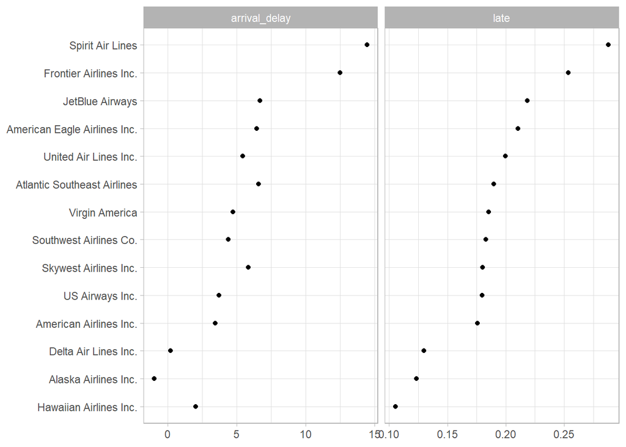

```r
results$dplyr |> left_join(airlines |> rename(airline_name = AIRLINE), by = c("AIRLINE" = "IATA_CODE")) |>
  mutate(airline_name = fct_reorder(airline_name, late)) |>
  pivot_longer(c(arrival_delay, late), names_to = "statistic") |>
  ggplot(aes(value, airline_name)) + geom_point() + facet_wrap(~ statistic, scales = "free_x") + labs(x = NULL, y = NULL)
```

```r
flights_db |> group_by(AIRLINE) |> summarise(arrival_delay = mean(ARRIVAL_DELAY, na.rm = TRUE)) |> show_query()
```

```
<SQL>
SELECT AIRLINE, AVG(ARRIVAL_DELAY) AS arrival_delay
FROM flights
GROUP BY AIRLINE
```

```r
rm(flights_full)  # the next parts use the sample
invisible(gc())
```

**Conclusion** Spirit (NK) and Frontier (F9), two low-cost airlines, have the largest mean delays ($15$ and $12$ minutes) and the most flights arriving more than $15$ minutes late ($29\%$ and $25\%$), while Alaska, Delta and Hawaiian are on time on average, with $11$ to $13\%$ of late flights. The `dplyr` verbs applied to the DuckDB table are translated into SQL by `dbplyr` (`SELECT AIRLINE, AVG(ARRIVAL_DELAY) ... GROUP BY AIRLINE`) and executed by the database: the same code works on a data frame, a database or (with `sparklyr`) a cluster.

## 3. Profiling and optimizing

The cumulated arrival delay along the year can be computed with `cumsum`. To understand where the time goes, we write this function ourselves (PC7, *Complexity of cumulative sums*).

```r
cumsum_0 <- function(x) {
  res <- numeric(0)
  for (i in seq_along(x)) {
    res[i] <- 0
    for (j in seq_len(i)) res[i] <- res[i] + x[j]
  }
  res
}
```

**Question** *Predict before you run:* how does the time of `cumsum_0` grow with the length $n$ of `x`? Measure it for $n = 250, 500, 1000, 2000$ and plot it in log-log scale.

**Answer**

```r
scaling <- tibble(n = c(250, 500, 1000, 2000)) |>
  mutate(time = map_dbl(n, \(n) { x <- rnorm(n); as.numeric(bench::mark(cumsum_0(x), iterations = 3)$median) }))
scaling
```

```
# A tibble: 4 × 2
      n    time
  <dbl>   <dbl>
1   250 0.00359
2   500 0.0140
3  1000 0.0497
4  2000 0.205
```

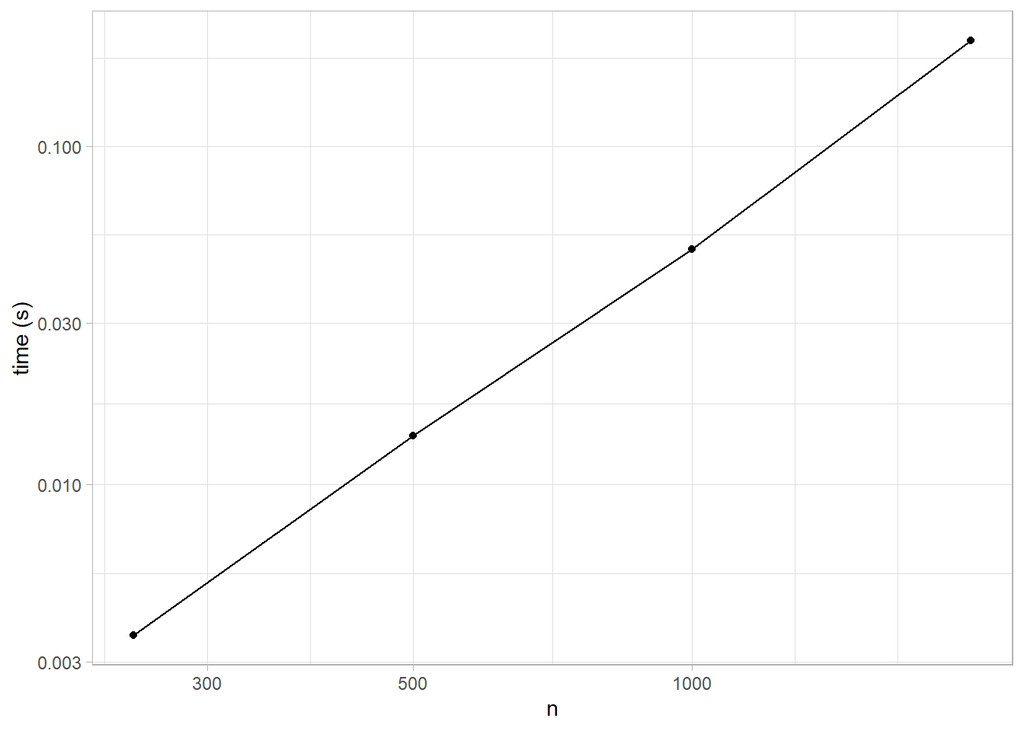

```r
ggplot(scaling, aes(n, time)) + geom_point() + geom_line() + scale_x_log10() + scale_y_log10() + labs(y = "time (s)")
```

```r
coef(lm(log(time) ~ log(n), data = scaling))[2]
```

```
  log(n)
1.934151
```

**Conclusion** The time of `cumsum_0` grows like $n^2$: the slope in log-log scale is close to $2$ (between $1.8$ and $2$ depending on the run, the small sizes being dominated by constant costs), as expected from the $n(n-1)/2$ additions of the double loop (PC7, *Complexity of cumulative sums*). For the $582\,000$ flights, it would take hours.

**Question** Write `cumsum_1` with a single loop (`res[i] <- res[i - 1] + x[i]`) growing the result vector, `cumsum_2` with a preallocated result (`numeric(length(x))`), and compare them with the built-in `cumsum` for $n = 10^5$. Then, if a compiler is available (`pkgbuild::has_build_tools()`), compile the C++ functions of `cumsum.cc` with `Rcpp::sourceCpp` and add them to the comparison.

**Answer**

```r
cumsum_1 <- function(x) {
  res <- x[1]
  for (i in seq_along(x)[-1]) res[i] <- res[i - 1] + x[i]
  res
}
cumsum_2 <- function(x) {
  res <- numeric(length(x))
  res[1] <- x[1]
  for (i in seq_along(x)[-1]) res[i] <- res[i - 1] + x[i]
  res
}
x <- rnorm(1e5)
candidates <- list(`loop, growing vector` = quote(cumsum_1(x)), `loop, preallocated` = quote(cumsum_2(x)), `built-in cumsum` = quote(cumsum(x)))
if (pkgbuild::has_build_tools()) {
  Rcpp::sourceCpp("cumsum.cc")
  candidates <- c(candidates, list(`Rcpp loop` = quote(cumsum_4(x)), `Rcpp std::partial_sum` = quote(cumsum_5(x))))
}
timings <- bench::mark(exprs = candidates, iterations = 10, check = TRUE, filter_gc = FALSE)
timings |> transmute(version = names(candidates), median, mem_alloc, `relative to cumsum` = as.numeric(median) / as.numeric(median[3]))
```

```
# A tibble: 5 × 4
  version                 median mem_alloc `relative to cumsum`
  <chr>                 <bch:tm> <bch:byt>                <dbl>
1 loop, growing vector    36.3ms   18.11MB               37.0
2 loop, preallocated      10.9ms    2.32MB               11.1
3 built-in cumsum        980.9µs   781.3KB                1
4 Rcpp loop              961.5µs   781.3KB                0.980
5 Rcpp std::partial_sum  607.2µs   781.3KB                0.619
```

**Conclusion** With a single loop, the algorithm is linear, but its R implementation is still $10$ to $15$ times slower than the built-in `cumsum` when the result is preallocated, and about $40$ times slower when the vector grows at each step (which also allocates $8$ times more memory; recent versions of R grow vectors in place by blocks, which limits the damage compared with the theoretical $O(n^2)$ copies). The compiled C++ loop (`Rcpp`) is as fast as the built-in `cumsum` (itself written in C), and `std::partial_sum` is even a little faster. The order of the optimizations matters: first the algorithm ($O(n^2) \to O(n)$), then the memory management, then the language.

**Question** Profile the computation of the cumulated delay along the year (sort the flights by date and departure time, compute the cumulated sum, build the dates, plot) with `profvis`. Which step takes the most time? Is `cumsum` worth optimizing?

**Answer**

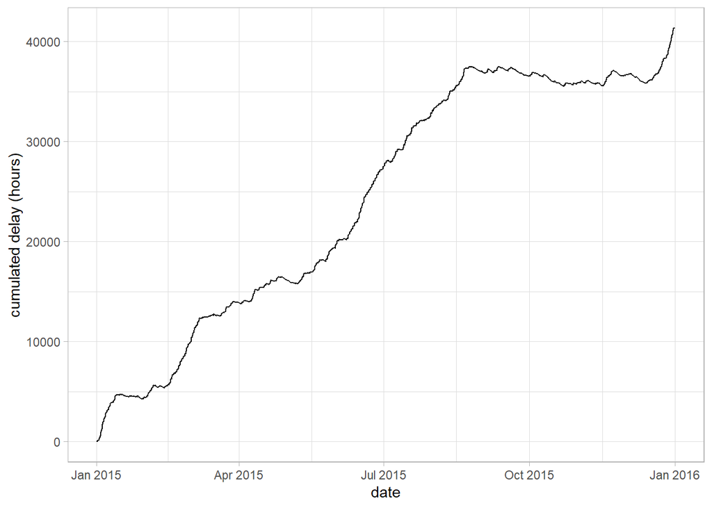

[interactive chart not shown]

```r
profvis::profvis({
  timeline <- flights |> arrange(MONTH, DAY, SCHEDULED_DEPARTURE) |>
    mutate(cumulated_delay = cumsum(replace_na(ARRIVAL_DELAY, 0)),
           date = make_datetime(YEAR, MONTH, DAY, as.integer(substr(SCHEDULED_DEPARTURE, 1, 2)), as.integer(substr(SCHEDULED_DEPARTURE, 3, 4))))
  print(ggplot(timeline, aes(date, cumulated_delay / 60)) + geom_line() + labs(y = "cumulated delay (hours)"))
})
```

**Conclusion** The profile shows that `cumsum` takes almost no time (a few milliseconds): most of the time goes to drawing the plot (more than $1$ s for half a million points), then to sorting the flights and building the dates (a few tenths of a second each). Optimizing `cumsum` would be useless here: a profiler shows where the time actually goes, which is rarely where we expect. The cumulated delay reaches about $41\,000$ hours over the year for the $10\%$ sample.

## 4. Parallel cross validation

We want to predict the arrival delay from the information available at the departure. We compare $5$ linear models by an $8$-fold cross validation (note: in a formula, `DEPARTURE_DELAY/SCHEDULED_TIME` means *nesting*, not a ratio: the ratio is written `I(DEPARTURE_DELAY / SCHEDULED_TIME)`).

```r
flights_model_data <- flights |> select(ARRIVAL_DELAY, DEPARTURE_DELAY, SCHEDULED_TIME, AIRLINE) |> drop_na()
formulas <- c("ARRIVAL_DELAY ~ DEPARTURE_DELAY",
              "ARRIVAL_DELAY ~ DEPARTURE_DELAY + SCHEDULED_TIME",
              "ARRIVAL_DELAY ~ DEPARTURE_DELAY + SCHEDULED_TIME + I(DEPARTURE_DELAY / SCHEDULED_TIME)",
              "ARRIVAL_DELAY ~ DEPARTURE_DELAY + SCHEDULED_TIME + I(DEPARTURE_DELAY / SCHEDULED_TIME) + AIRLINE",
              "ARRIVAL_DELAY ~ (DEPARTURE_DELAY + SCHEDULED_TIME + I(DEPARTURE_DELAY / SCHEDULED_TIME)) * AIRLINE")
set.seed(2)
folds <- sample(rep(1:8, length.out = nrow(flights_model_data)))
cv_rmse <- function(formula, fold, data, folds) {
  fit <- lm(as.formula(formula), data = data[folds != fold, ])
  sqrt(mean((predict(fit, data[folds == fold, ]) - data$ARRIVAL_DELAY[folds == fold])^2))
}
tasks <- expand_grid(formula = formulas, fold = 1:8)
```

**Question** Compute the $40$ cross validation errors sequentially with `map2_dbl`, and display the mean CV RMSE of each model. Which model would you choose?

**Answer**

```r
sequential_time <- system.time(
  tasks$rmse <- map2_dbl(tasks$formula, tasks$fold, cv_rmse, data = flights_model_data, folds = folds)
)[["elapsed"]]
tasks |> group_by(formula) |> summarise(`CV RMSE` = mean(rmse), `fold SD` = sd(rmse)) |>
  mutate(model = match(formula, formulas), .before = 1) |> arrange(model) |> select(-formula)
```

```
# A tibble: 5 × 3
  model `CV RMSE` `fold SD`
  <int>     <dbl>     <dbl>
1     1      12.9    0.0593
2     2      12.7    0.0494
3     3      12.7    0.0497
4     4      12.5    0.0514
5     5      12.5    0.0521
```

```r
paired <- tasks |> mutate(model = match(formula, formulas)) |> filter(model %in% 4:5) |>
  select(fold, model, rmse) |> pivot_wider(names_from = model, values_from = rmse, names_prefix = "m")
summary(paired$m5 - paired$m4)
```

```
    Min.  1st Qu.   Median     Mean  3rd Qu.     Max.
-0.03114 -0.02642 -0.02499 -0.02359 -0.01892 -0.01656
```

```r
sequential_time
```

```
[1] 67.94
```

**Conclusion** The CV RMSE decreases from $12.9$ minutes (departure delay only) to $12.7$ with the scheduled time and the ratio, and to $12.5$ with the airline effects (models $4$ and $5$, similar to the displayed precision): the arrival delay is mostly the departure delay, and the other variables only bring small corrections. The paired differences compare both models on each validation fold. Their spread is descriptive because the training sets overlap. Model $5$ reduced fold RMSE by $0.017$ to $0.031$ minutes (mean $0.024$, about $1.4$ seconds). We choose model $4$ for its simpler specification.

**Question** Start $4$ background R processes with `mirai::daemons(4)`, and run the same computation in parallel with `map2_dbl(..., .f = in_parallel(\(formula, fold) ..., cv_rmse = cv_rmse, data = flights_model_data, folds = folds))`: the function sent to the workers must be self-contained, its objects being passed explicitly. Compare the times. Then measure the time of a parallel computation whose tasks are tiny (e.g. the mean of $100$ numbers, $40$ times). Explain the results with PC7, *Speed-up laws*.

**Answer**

```r
mirai::daemons(4)
parallel_time <- system.time(
  parallel_rmse <- map2_dbl(tasks$formula, tasks$fold,
                            in_parallel(\(formula, fold) cv_rmse(formula, fold, data, folds),
                                        cv_rmse = cv_rmse, data = flights_model_data, folds = folds))
)[["elapsed"]]
tiny <- bench::mark(sequential = map_dbl(1:40, \(i) mean(rnorm(100))),
                    parallel = map_dbl(1:40, in_parallel(\(i) mean(rnorm(100)))), iterations = 5, check = FALSE)
mirai::daemons(0)
c(`same results` = isTRUE(all.equal(parallel_rmse, tasks$rmse)), sequential = sequential_time, `parallel (4 workers)` = parallel_time,
  `speed-up` = sequential_time / parallel_time)
```

```
        same results           sequential parallel (4 workers)
            1.000000            67.940000            13.290000
            speed-up
            5.112114
```

```r
tiny |> transmute(version = as.character(expression), median)
```

```
# A tibble: 2 × 2
  version      median
  <chr>      <bch:tm>
1 sequential   1.27ms
2 parallel    11.09ms
```

## 5. Serving a model

The chosen model has to be made available: to people through a web application, to other programs through a REST API.

**Question** Fit the fourth model on all the data. What is its size in memory? Which of its components take the space? Reduce it with `butcher::butcher()`; then remove by hand the components that `predict` does not need (the $QR$ decomposition matrix `qr$qr`, the `effects`, the `residuals` and the `model` data frame). Check that its predictions are unchanged, and save it in `flights_model.rds`.

**Answer**

```r
flights_model <- lm(ARRIVAL_DELAY ~ DEPARTURE_DELAY + SCHEDULED_TIME + I(DEPARTURE_DELAY / SCHEDULED_TIME) + AIRLINE, data = flights_model_data)
sizes <- map_dbl(flights_model, \(component) as.numeric(lobstr::obj_size(component)))
head(sort(sizes, decreasing = TRUE), 5) / 1e6
```

```
           qr         model       effects     residuals fitted.values
    77.714840     22.862984      9.143720      4.572648      4.572648
```

```r
butchered <- butcher::butcher(flights_model)
small_model <- butchered
small_model$qr$qr <- NULL                                  # predict only needs the rank and the pivot of the QR decomposition
small_model[c("effects", "residuals", "model")] <- NULL
newdata <- tibble(DEPARTURE_DELAY = c(0, 30, 120), SCHEDULED_TIME = c(60, 180, 300), AIRLINE = c("AA", "DL", "WN"))
saveRDS(small_model, "flights_model.rds")
c(`full model (MB)` = as.numeric(lobstr::obj_size(flights_model)) / 1e6, `butchered model (MB)` = as.numeric(lobstr::obj_size(butchered)) / 1e6,
  `reduced by hand (MB)` = as.numeric(lobstr::obj_size(small_model)) / 1e6,
  `same predictions` = isTRUE(all.equal(predict(flights_model, newdata), predict(small_model, newdata))))
```

```
     full model (MB) butchered model (MB) reduced by hand (MB)
           118.86590            114.29478              0.01108
    same predictions
             1.00000
```

The file `flights_api.R` describes a REST API with `plumber2`: comments `#*` above a function declare the route (`@get /predict`), the expected query parameters and their types, and the format of the answer.

```r
cat(readLines("flights_api.R"), sep = "\n")
```

```
# A REST API serving the arrival delay model of Lab 7 (plumber2).
# Run it with: plumber2::api("flights_api.R") |> plumber2::api_run(port = 8000)
# and query it with: http://127.0.0.1:8000/predict?departure_delay=30&scheduled_time=180&airline=AA

flights_model <- readRDS("flights_model.rds")

#* Predict the arrival delay of a flight
#* @get /predict
#* @query departure_delay:number Departure delay (minutes)
#* @query scheduled_time:number Scheduled flight time (minutes)
#* @query airline:string Airline IATA code (AA, DL, WN...)
#* @serializer unboxedJSON
function(query) {
  if (is.null(query$airline) || !query$airline %in% flights_model$xlevels$AIRLINE) {
    return(list(error = "unknown airline"))
  }
  newdata <- data.frame(DEPARTURE_DELAY = query$departure_delay, SCHEDULED_TIME = query$scheduled_time,
                        AIRLINE = factor(query$airline, levels = flights_model$xlevels$AIRLINE))
  list(arrival_delay = unname(predict(flights_model, newdata)))
}
```

**Question** Start the API in a background R process (`callr::r_bg`), wait until it answers, and query it with `httr2` for a flight of American Airlines with a departure delay of $30$ minutes and a scheduled time of $180$ minutes. Compare with `predict`. Then write a `testthat` test of the API that does not need a running server (`plumber2::api("flights_api.R")$test_request(fiery::fake_request(url))`).

**Answer**

```r
server <- callr::r_bg(\() plumber2::api("flights_api.R") |> plumber2::api_run(port = 8765, block = TRUE, showcase = FALSE))
request <- httr2::request("http://127.0.0.1:8765/predict") |>
  httr2::req_url_query(departure_delay = 30, scheduled_time = 180, airline = "AA") |>
  httr2::req_retry(max_tries = 20, retry_on_failure = TRUE, backoff = \(i) 1)
answer <- httr2::resp_body_json(httr2::req_perform(request))
server$kill()
```

```
[1] TRUE
```

```r
c(API = answer$arrival_delay, predict = unname(predict(small_model, tibble(DEPARTURE_DELAY = 30, SCHEDULED_TIME = 180, AIRLINE = "AA"))))
```

```
     API  predict
24.46030 24.46034
```

```r
library(testthat)
test_that("the API predicts the arrival delay and rejects unknown airlines", {
  api <- plumber2::api("flights_api.R")
  query <- function(url) {
    body <- api$test_request(fiery::fake_request(url))$body
    jsonlite::fromJSON(if (is.raw(body)) rawToChar(body) else body)
  }
  ok <- query("http://localhost/predict?departure_delay=30&scheduled_time=180&airline=AA")
  expect_equal(ok$arrival_delay, unname(predict(small_model, tibble(DEPARTURE_DELAY = 30, SCHEDULED_TIME = 180, AIRLINE = "AA"))), tolerance = 1e-4)  # JSON keeps 4 significant digits
  expect_equal(query("http://localhost/predict?departure_delay=30&scheduled_time=180&airline=XX")$error, "unknown airline")
})
```

```
Test passed with 2 successes 🎉.
```

**Conclusion** The API started in a background process answers $24.46$ minutes for an American Airlines flight leaving $30$ minutes late for a $3$-hour flight, the prediction of the model (the JSON answer keeps $4$ significant digits). The test does not need a running server: `test_request` sends a fake request through the API object, which makes it fast and usable in continuous integration. It checks both a correct answer and the error message for an unknown airline: an API must be tested on its failures too.

The file `flights_app.R` is a `shiny` application, with a `bslib` layout, using the same model: run it from RStudio (*Run App*) or with `shiny::runApp("flights_app.R")`.

```r
cat(readLines("flights_app.R"), sep = "\n")
```

```
# A Shiny application (bslib) predicting the arrival delay of a flight with the model of Lab 7.
# Run it from RStudio (Run App) or with: shiny::runApp("flights_app.R")
library(shiny)
library(bslib)

flights_model <- readRDS("flights_model.rds")
airlines <- flights_model$xlevels$AIRLINE

ui <- page_sidebar(
  title = "Arrival delay prediction",
  sidebar = sidebar(
    sliderInput("departure_delay", "Departure delay (min)", min = -30, max = 180, value = 0, step = 1),
    sliderInput("scheduled_time", "Scheduled flight time (min)", min = 20, max = 600, value = 120, step = 5),
    selectInput("airline", "Airline", airlines)
  ),
  value_box(title = "Predicted arrival delay", value = textOutput("prediction"), showcase = bsicons::bs_icon("airplane"))
)

server <- function(input, output) {
  output$prediction <- renderText({
    newdata <- data.frame(DEPARTURE_DELAY = input$departure_delay, SCHEDULED_TIME = input$scheduled_time,
                          AIRLINE = factor(input$airline, levels = airlines))
    sprintf("%.0f min", predict(flights_model, newdata))
  })
}

shinyApp(ui, server)
```

## To go further

The following blocks are optional and independent: each of them only uses the objects defined in the core part. Their difficulty is marked by stars: ★ direct extension, ★★ new method, ★★★ longer or research-flavored.

| Block | Lecture | Stars |
| --- | --- | --- |
| Map/Reduce by hand | Map/Reduce | ★★ |
| Larger than memory | Data size | ★★ |
| The memory hierarchy | Hardware | ★★ |
| How many workers? | Parallelization | ★ |
| Spark with sparklyr | Distributed computing | ★★ |
| A reproducible pipeline with targets | Workflows | ★★ |
| In-database scoring with orbital | Serving | ★★ |
| Versioning and deploying a model | MLOps | ★★ |
| The same computations in Python | Tools | ★ |

### Map/Reduce by hand (★★)

In the Map/Reduce model, each partition of the data computes a small summary (*map*) and the summaries are merged (*reduce*). The least squares estimate only needs $\mathbb{X}^\top\mathbb{X}$ and $\mathbb{X}^\top\mathbf{Y}$, which are sums over the partitions (PC7, *Map/Reduce for statistics*).

**Question** For each monthly partition of the Parquet dataset, compute the number of flights, the mean and the sum of squared deviations of the arrival delay, and the matrices $\mathbb{X}_k^\top\mathbb{X}_k$ and $\mathbb{X}_k^\top\mathbf{Y}_k$ for the model `ARRIVAL_DELAY ~ DEPARTURE_DELAY + SCHEDULED_TIME`. Merge them, and compare the mean, the variance and the coefficients with the computations on the whole data.

**Answer**

```r
summaries <- map(1:12, function(m) {
  part <- open_dataset("data/flights_parquet") |> filter(MONTH == !!m) |>
    select(ARRIVAL_DELAY, DEPARTURE_DELAY, SCHEDULED_TIME) |> collect() |> drop_na()
  X <- cbind(1, part$DEPARTURE_DELAY, part$SCHEDULED_TIME)
  list(n = as.numeric(nrow(part)),                         # a double: n_A * n_B would overflow the integers
       mean = mean(part$ARRIVAL_DELAY), M = sum((part$ARRIVAL_DELAY - mean(part$ARRIVAL_DELAY))^2),
       XtX = crossprod(X), XtY = crossprod(X, part$ARRIVAL_DELAY))
})
merged <- reduce(summaries, function(a, b) {
  n <- a$n + b$n
  list(n = n, mean = (a$n * a$mean + b$n * b$mean) / n, M = a$M + b$M + a$n * b$n / n * (a$mean - b$mean)^2,
       XtX = a$XtX + b$XtX, XtY = a$XtY + b$XtY)
})
whole <- flights |> select(ARRIVAL_DELAY, DEPARTURE_DELAY, SCHEDULED_TIME) |> drop_na()
rbind(`map/reduce` = c(mean = merged$mean, variance = merged$M / (merged$n - 1), solve(merged$XtX, merged$XtY)[, 1]),
      `whole data` = c(mean(whole$ARRIVAL_DELAY), var(whole$ARRIVAL_DELAY), coef(lm(ARRIVAL_DELAY ~ DEPARTURE_DELAY + SCHEDULED_TIME, data = whole))))
```

```
               mean variance
map/reduce 4.339297 1533.113 -0.7661426 1.00659 -0.02947834
whole data 4.339297 1533.113 -0.7661426 1.00659 -0.02947834
```

**Conclusion** The merged summaries give exactly the mean, the variance and the coefficients of the least squares regression computed on the whole data: the means and the sums of squares are merged with Chan’s formula, and $\mathbb{X}^\top\mathbb{X}$ and $\mathbb{X}^\top\mathbf{Y}$ are sums over the partitions (PC7, *Map/Reduce for statistics*). Each month only sends a few numbers, whatever its size: this is how statistics are computed on distributed data. The count must be stored as a double: the products of counts overflow R’s 32-bit integers.

### Larger than memory (★★)

DuckDB can compute on data larger than the memory it is allowed to use: it streams through the files in chunks, and writes its intermediate results to disk if needed. A median or a quantile is harder than a mean: it is not a mergeable statistic (PC7, *Map/Reduce*), so the values of each group have to be kept or sorted.

**Question** If the full CSV file `data/flights.csv.gz` is available (it is not downloaded automatically: $195$ MB), limit the memory of DuckDB to $500$ MB (`SET memory_limit = '500MB'`) and compute, directly from the compressed CSV file, the number of flights, the median and the $90\%$ quantile of the arrival delay of the $10$ busiest origin airports, with their names (a join with `data/airports.csv`). Measure the time and the memory of the R session.

**Answer**

```r
if (file.exists("data/flights.csv.gz")) {
  dbExecute(con, "SET memory_limit = '500MB'")
  dbExecute(con, "SET threads = 4")                         # fewer reading buffers at the same time
  dbExecute(con, "SET preserve_insertion_order = false")    # the order of the rows does not matter here
  dbExecute(con, sprintf("SET temp_directory = '%s'", gsub("\\\\", "/", file.path(tempdir(), "duckdb"))))  # where DuckDB spills
  memory_before <- lobstr::mem_used()
  start <- Sys.time()
  airports_delays <- dbGetQuery(con, "
    SELECT f.ORIGIN_AIRPORT AS airport, a.AIRPORT AS name, COUNT(*) AS flights,
           MEDIAN(f.ARRIVAL_DELAY) AS median_delay, QUANTILE_CONT(f.ARRIVAL_DELAY, 0.9) AS q90_delay
    FROM read_csv_auto('data/flights.csv.gz', types = {'ORIGIN_AIRPORT': 'VARCHAR', 'DESTINATION_AIRPORT': 'VARCHAR'}) f
    JOIN read_csv_auto('data/airports.csv') a ON f.ORIGIN_AIRPORT = a.IATA_CODE
    GROUP BY ALL ORDER BY flights DESC LIMIT 10")
  print(c(`time (s)` = as.numeric(difftime(Sys.time(), start, units = "secs")),
          `R memory change (MB)` = as.numeric(lobstr::mem_used() - memory_before) / 1e6))
  for (setting in c("memory_limit", "threads", "preserve_insertion_order")) dbExecute(con, paste("RESET", setting))
  as_tibble(airports_delays)
} else {
  message("data/flights.csv.gz is not available")
}
```

```
            time (s) R memory change (MB)
            7.545544            -0.135984
```

```
# A tibble: 10 × 5
   airport name                                   flights median_delay q90_delay
   <chr>   <chr>                                    <dbl>        <dbl>     <dbl>
 1 ATL     Hartsfield-Jackson Atlanta Internatio…  346836           -6        29
 2 ORD     Chicago O'Hare International Airport    285884           -4        51
 3 DFW     Dallas/Fort Worth International Airpo…  239551           -4        41
 4 DEN     Denver International Airport            196055           -3        42
 5 LAX     Los Angeles International Airport       194673           -3        37
 6 SFO     San Francisco International Airport     148008           -4        39
 7 PHX     Phoenix Sky Harbor International Airp…  146815           -3        31
 8 IAH     George Bush Intercontinental Airport    146622           -3        40
 9 LAS     McCarran International Airport          133181           -3        37
10 MSP     Minneapolis-Saint Paul International …  112117           -6        29
```

**Conclusion** DuckDB computes the median and the $90\%$ quantile of the delays of the busiest airports directly from the compressed CSV file in a few seconds, with at most $500$ MB of memory, and the memory of the R session does not change: it streams through the file, keeping only the two needed columns. Most flights arrive early or on time (the medians are between $-6$ and $-3$ minutes), but the tails differ: $10\%$ of the flights leaving Chicago O’Hare arrive more than $51$ minutes late, against $29$ minutes for Atlanta and Minneapolis. A median or a quantile is not a mergeable statistic: DuckDB keeps the values of each airport (and would spill them to disk if needed), while the means of Part 2 only need sums and counts.

### The memory hierarchy (★★)

R matrices are stored column by column: reading a column reads contiguous memory, reading a row jumps from one column to the next. The caches of the processor load memory by blocks (*cache lines*), so that contiguous accesses are much faster.

**Question** For a $5000 \times 5000$ matrix, compare the time to sum its columns one by one (`m[, j]`) and its rows one by one (`m[i, ]`). Compare also `colSums` and `rowSums`.

**Answer**

```r
m <- matrix(rnorm(5000 * 5000), 5000, 5000)
bench::mark(`columns one by one` = for (j in 1:5000) sum(m[, j]), `rows one by one` = for (i in 1:5000) sum(m[i, ]),
            colSums = colSums(m), rowSums = rowSums(m), iterations = 3, check = FALSE, filter_gc = FALSE) |>
  transmute(loop = as.character(expression), median)
```

```
# A tibble: 4 × 2
  loop                 median
  <chr>              <bch:tm>
1 columns one by one  223.5ms
2 rows one by one     665.2ms
3 colSums                34ms
4 rowSums              56.2ms
```

```r
rm(m)
```

### How many workers? (★)

**Question** Run the $40$ tasks of the cross validation of Part 4 with $1$, $2$, $4$ and $8$ `mirai` workers (`mirai::daemons(k)`; at most $4$ on a machine with few cores, such as Colab: each worker holds a copy of the data and of its fits, about $1$ GB here), and plot the speed-up against the number of workers, with the number of cores of your machine (`parallel::detectCores()`). Fit Amdahl’s law $S(P) = 1/((1-f) + f/P)$ to the measured speed-ups. What limits the speed-up? (PC7, *Speed-up laws*.)

**Answer**

```r
cv_all <- function() map2_dbl(tasks$formula, tasks$fold, in_parallel(\(formula, fold) cv_rmse(formula, fold, data, folds),
                                                                       cv_rmse = cv_rmse, data = flights_model_data, folds = folds))
n_workers <- c(1, 2, 4, 8)
n_workers <- n_workers[n_workers <= max(4, parallel::detectCores())]  # 8 workers would exhaust the memory of Colab
speed_up <- map_dfr(n_workers, function(k) {
  mirai::daemons(k)
  cv_all()                                                 # a first call sends the data to the workers
  elapsed <- system.time(cv_all())[["elapsed"]]
  mirai::daemons(0)
  tibble(workers = k, time = elapsed)
}) |> mutate(`speed-up` = time[1] / time)
amdahl <- nls(`speed-up` ~ 1 / ((1 - f) + f / workers), data = speed_up, start = list(f = 0.9))
speed_up
```

```
# A tibble: 4 × 3
  workers  time `speed-up`
    <dbl> <dbl>      <dbl>
1       1  26.8       1
2       2  15.6       1.72
3       4  13.7       1.96
4       8  11.5       2.34
```

```r
c(cores = parallel::detectCores(), `parallel fraction f` = coef(amdahl)[["f"]])
```

```
              cores parallel fraction f
          22.000000            0.661419
```

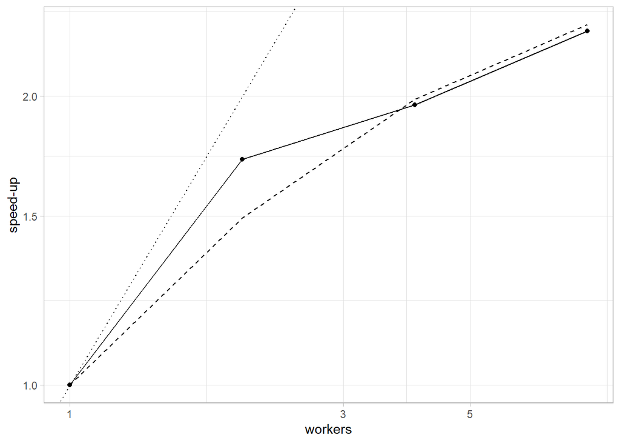

```r
ggplot(speed_up, aes(workers, `speed-up`)) + geom_point() + geom_line() +
  geom_line(aes(y = predict(amdahl)), linetype = "dashed") + geom_abline(linetype = "dotted") + scale_x_log10() + scale_y_log10()
```

### Spark with sparklyr (★★)

Spark distributes the data and the computations over a cluster; locally, it runs on the cores of the machine, which is enough to learn its interface. `sparklyr` translates the `dplyr` verbs into Spark SQL, and gives access to the distributed machine learning library MLlib. Spark needs Java ($17$ or $21$) and is installed once with `spark_install()` (about $400$ MB). On Linux, macOS and Colab, nothing else is needed. On Windows, Spark also needs Hadoop’s `winutils.exe`, a small program that is not shipped with Spark: download it once (from the `winutils` repository of Steve Loughran on GitHub, the source suggested by `sparklyr`) and copy it into the folder `tmp\hadoop\bin` of the Spark installation (given by `sparklyr::spark_home_dir()`), where `sparklyr` looks for it. The next chunk does it (it is not run automatically); without it, `spark_connect` stops with a message giving the same instructions.

```r
# Windows only, once (after sparklyr::spark_install()): Hadoop's winutils.exe, where sparklyr looks for it
# (nothing is done on Linux, macOS and Colab, or if Spark is not installed)
if (.Platform$OS.type == "windows" && nrow(sparklyr::spark_installed_versions()) > 0) {
  winutils_dir <- file.path(sparklyr::spark_home_dir(), "tmp", "hadoop", "bin")
  dir.create(winutils_dir, recursive = TRUE, showWarnings = FALSE)
  download.file("https://github.com/steveloughran/winutils/raw/master/hadoop-3.0.0/bin/winutils.exe",
                file.path(winutils_dir, "winutils.exe"), mode = "wb")
}
```

**Question** Copy the flights to a local Spark session, compute the mean delay by airline with `dplyr` verbs and with an SQL query, and fit the third model with `ml_linear_regression`. Compare its coefficients with `lm`.

**Answer**

```r
sc <- NULL
old_wd <- setwd(tempdir())  # Spark writes its logs (derby.log, logs/) in the working directory
if (requireNamespace("sparklyr", quietly = TRUE) && nzchar(Sys.which("java")) &&
    nrow(sparklyr::spark_installed_versions()) > 0) {
  # sparklyr explains what is missing (e.g. Hadoop's winutils.exe on Windows, and where to copy it)
  sc <- tryCatch(sparklyr::spark_connect(master = "local[4]"),
                 error = function(e) { message("Spark could not start: ", conditionMessage(e)); NULL })
}
if (!is.null(sc)) {
  library(sparklyr)
  flights_spark <- copy_to(sc, flights_model_data |> mutate(RATIO = DEPARTURE_DELAY / SCHEDULED_TIME), "flights", overwrite = TRUE)
  print(flights_spark |> group_by(AIRLINE) |> summarise(arrival_delay = mean(ARRIVAL_DELAY, na.rm = TRUE)) |> arrange(AIRLINE) |> collect())
  print(DBI::dbGetQuery(sc, "SELECT AIRLINE, AVG(ARRIVAL_DELAY) AS arrival_delay FROM flights GROUP BY AIRLINE ORDER BY AIRLINE LIMIT 3"))
  spark_fit <- ml_linear_regression(flights_spark, ARRIVAL_DELAY ~ DEPARTURE_DELAY + SCHEDULED_TIME + RATIO + AIRLINE)
  print(head(cbind(spark = coef(spark_fit)[1:4], lm = coef(flights_model)[1:4])))
  spark_disconnect(sc)
} else {
  message("Spark is not available: install Java 17 or 21, then run sparklyr::spark_install() (on Windows, sparklyr also asks for Hadoop's winutils.exe)")
}
```

```
# A tibble: 14 × 2
   AIRLINE arrival_delay
   <chr>           <dbl>
 1 AA              3.35
 2 AS             -0.649
 3 B6              6.44
 4 DL              0.159
 5 EV              6.36
 6 F9             11.9
 7 HA              2.36
 8 MQ              6.14
 9 NK             14.6
10 OO              5.83
11 UA              5.47
12 US              3.55
13 VX              4.24
14 WN              4.33
  AIRLINE arrival_delay
1      AA     3.3468686
2      AS    -0.6488134
3      B6     6.4402104
                      spark          lm
(Intercept)      0.92577348 -0.92273552
DEPARTURE_DELAY  0.99130769  0.99130769
SCHEDULED_TIME  -0.02604171 -0.02604171
RATIO            1.98814331  1.98814331
```

```r
setwd(old_wd)
```

**Conclusion** The `dplyr` verbs and the SQL query give the same mean delays as the other engines ($3.35$ minutes for AA, $-0.65$ for AS). `ml_linear_regression` gives the same slopes as `lm` ($0.991$ for the departure delay, $1.99$ for the ratio), computed in a distributed way (by Map/Reduce over the partitions, as in the first block), but not the same intercept ($0.93$ against $-0.92$): the two parametrizations of the airline differ. `lm` takes the first airline in alphabetical order (AA) as reference, while Spark’s formula orders the airlines by frequency and drops the least frequent one (VX): the intercept of Spark is the one of `lm` plus the coefficient of VX in `lm` ($-0.92 + 1.85 = 0.93$), and the fitted values are the same. On data that fit in memory, Spark is much slower than DuckDB or `data.table`: its overhead (JVM, scheduling, serialization) only pays off on a cluster, for data that do not fit on one machine.

### A reproducible pipeline with targets (★★)

A pipeline declares the steps of an analysis and their dependencies; `targets` only reruns the steps whose code or inputs changed, and can run independent steps in parallel (with `crew`).

**Question** Write a `_targets.R` file with three targets (read the Parquet data, fit the model, compute its RMSE), run it twice with `tar_make()` in a temporary folder, and check that nothing is recomputed the second time. Then change the model and run it again.

**Answer**

```r
pipeline_dir <- file.path(tempdir(), "flights_pipeline")
dir.create(pipeline_dir, showWarnings = FALSE)
file.copy("data/flights_parquet", pipeline_dir, recursive = TRUE)
```

```
[1] TRUE
```

```r
write_pipeline <- function(formula) writeLines(c(
  'library(targets)',
  'tar_option_set(packages = c("arrow", "dplyr", "tidyr"))',
  'list(',
  '  tar_target(data, arrow::open_dataset("flights_parquet") |> select(ARRIVAL_DELAY, DEPARTURE_DELAY, SCHEDULED_TIME) |> collect() |> drop_na()),',
  sprintf('  tar_target(model, lm(%s, data = data)),', formula),
  '  tar_target(rmse, sqrt(mean(residuals(model)^2)))',
  ')'), file.path(pipeline_dir, "_targets.R"))
run <- function() callr::r(\(dir) { setwd(dir); targets::tar_make(reporter = "silent"); targets::tar_meta(fields = c("time", "seconds")) },
                           args = list(pipeline_dir))
write_pipeline("ARRIVAL_DELAY ~ DEPARTURE_DELAY")
run_1 <- run(); run_2 <- run()
write_pipeline("ARRIVAL_DELAY ~ DEPARTURE_DELAY + SCHEDULED_TIME")
run_3 <- run()
list(`first run` = run_1 |> select(name, time), `second run` = run_2 |> select(name, time), `after changing the model` = run_3 |> select(name, time))
```

```
$`first run`
# A tibble: 3 × 2
  name  time
  <chr> <dttm>
1 data  2026-11-24 22:51:52
2 model 2026-11-24 22:51:57
3 rmse  2026-11-24 22:51:57

$`second run`
# A tibble: 3 × 2
  name  time
  <chr> <dttm>
1 data  2026-11-24 22:51:52
2 model 2026-11-24 22:51:57
3 rmse  2026-11-24 22:51:57

$`after changing the model`
# A tibble: 3 × 2
  name  time
  <chr> <dttm>
1 data  2026-11-24 22:51:52
2 model 2026-11-24 22:52:13
3 rmse  2026-11-24 22:52:14
```

**Conclusion** The first `tar_make()` runs the three targets; the second one recomputes nothing (the times of the targets do not change): `targets` knows that neither their code nor their inputs changed. After changing the formula of the model, only the model and its RMSE are recomputed, not the reading of the data. On a long pipeline, this saves hours, and guarantees that the results correspond to the current code.

### In-database scoring with orbital (★★)

Instead of moving the data to the model, the model can be moved to the data: `orbital` translates a fitted `tidymodels` workflow into SQL expressions, which the database computes.

**Question** Fit the third model as a `tidymodels` workflow, convert it with `orbital::orbital()`, and compute the predictions inside DuckDB (`predict(orbital_object, flights_db)`). Display the generated SQL and check the predictions.

**Answer**

```r
library(tidymodels)
wf <- workflow(recipe(ARRIVAL_DELAY ~ DEPARTURE_DELAY + SCHEDULED_TIME + AIRLINE, data = flights_model_data) |>
                 step_mutate(RATIO = DEPARTURE_DELAY / SCHEDULED_TIME) |> step_dummy(AIRLINE),
               linear_reg()) |> fit(flights_model_data)
orbital_model <- orbital::orbital(wf)
print(orbital::orbital_sql(orbital_model, con))
```

```
<SQL> DEPARTURE_DELAY / SCHEDULED_TIME AS RATIO
<SQL> CASE WHEN (AIRLINE = 'AS') THEN 1.0 WHEN NOT (AIRLINE = 'AS') THEN 0.0 END AS AIRLINE_AS
<SQL> CASE WHEN (AIRLINE = 'B6') THEN 1.0 WHEN NOT (AIRLINE = 'B6') THEN 0.0 END AS AIRLINE_B6
<SQL> CASE WHEN (AIRLINE = 'DL') THEN 1.0 WHEN NOT (AIRLINE = 'DL') THEN 0.0 END AS AIRLINE_DL
<SQL> CASE WHEN (AIRLINE = 'EV') THEN 1.0 WHEN NOT (AIRLINE = 'EV') THEN 0.0 END AS AIRLINE_EV
<SQL> CASE WHEN (AIRLINE = 'F9') THEN 1.0 WHEN NOT (AIRLINE = 'F9') THEN 0.0 END AS AIRLINE_F9
<SQL> CASE WHEN (AIRLINE = 'HA') THEN 1.0 WHEN NOT (AIRLINE = 'HA') THEN 0.0 END AS AIRLINE_HA
<SQL> CASE WHEN (AIRLINE = 'MQ') THEN 1.0 WHEN NOT (AIRLINE = 'MQ') THEN 0.0 END AS AIRLINE_MQ
<SQL> CASE WHEN (AIRLINE = 'NK') THEN 1.0 WHEN NOT (AIRLINE = 'NK') THEN 0.0 END AS AIRLINE_NK
<SQL> CASE WHEN (AIRLINE = 'OO') THEN 1.0 WHEN NOT (AIRLINE = 'OO') THEN 0.0 END AS AIRLINE_OO
<SQL> CASE WHEN (AIRLINE = 'UA') THEN 1.0 WHEN NOT (AIRLINE = 'UA') THEN 0.0 END AS AIRLINE_UA
<SQL> CASE WHEN (AIRLINE = 'US') THEN 1.0 WHEN NOT (AIRLINE = 'US') THEN 0.0 END AS AIRLINE_US
<SQL> CASE WHEN (AIRLINE = 'VX') THEN 1.0 WHEN NOT (AIRLINE = 'VX') THEN 0.0 END AS AIRLINE_VX
<SQL> CASE WHEN (AIRLINE = 'WN') THEN 1.0 WHEN NOT (AIRLINE = 'WN') THEN 0.0 END AS AIRLINE_WN
<SQL> (((((((((((((((-0.922735520208855 + (DEPARTURE_DELAY * 0.991307686586343)) + (SCHEDULED_TIME * -0.0260417095573479)) + (RATIO * 1.98814330784088)) + (AIRLINE_AS * 3.06978384738578)) + (AIRLINE_B6 * 0.565198658705897)) + (AIRLINE_DL * -2.36791388503468)) + (AIRLINE_EV * 1.32714928102594)) + (AI…
```

```r
in_database <- predict(orbital_model, flights_db |> filter(!is.na(DEPARTURE_DELAY), !is.na(SCHEDULED_TIME))) |> head(5) |> collect()
in_r <- predict(wf, flights |> filter(!is.na(DEPARTURE_DELAY), !is.na(SCHEDULED_TIME)) |> head(5))
bind_cols(in_database |> rename(`in the database` = .pred), in_r |> rename(`in R` = .pred))
```

```
# A tibble: 5 × 2
  `in the database` `in R`
              <dbl>  <dbl>
1             10.7   10.7
2              1.93   1.93
3             -6.03  -6.03
4             -8.42  -8.42
5             -8.14  -8.14
```

**Conclusion** `orbital` translates the fitted workflow (the recipe, with the ratio and the dummy variables, and the linear model) into SQL expressions: the prediction is a long arithmetic expression that any database can compute. The predictions computed inside DuckDB are exactly those of R. The data do not leave the database, and no R process is needed to score millions of rows: the model is moved to the data rather than the data to the model.

### Versioning and deploying a model (★★)

`vetiver` bundles a model with the metadata needed to serve it, versions it on a *board* (`pins`: a folder, S3, Posit Connect…), and generates the files of an API and of a Docker image.

**Question** Create a `vetiver_model` from the workflow of the previous block, pin two versions of it on a temporary board, list the versions, and write the plumber file and the Dockerfile that would deploy it (`vetiver_write_plumber`, `vetiver_write_docker`). Read the Dockerfile: which parts guarantee that the deployed model is the one you tested?

**Answer**

```r
board <- pins::board_temp(versioned = TRUE)
v <- vetiver::vetiver_model(wf, "flights-delay")
vetiver::vetiver_pin_write(board, v)
vetiver::vetiver_pin_write(board, v)
print(pins::pin_versions(board, "flights-delay"))
```

```
# A tibble: 2 × 3
  version                created             hash
  <chr>                  <dttm>              <chr>
1 20261124T215253Z-56f90 2026-11-24 22:52:53 56f90
2 20261124T215307Z-56f90 2026-11-24 22:53:07 56f90
```

```r
deploy_dir <- file.path(tempdir(), "deploy")
dir.create(deploy_dir, showWarnings = FALSE)
vetiver::vetiver_write_plumber(board, "flights-delay", file = file.path(deploy_dir, "plumber.R"))
invisible(capture.output(vetiver::vetiver_write_docker(v, file.path(deploy_dir, "plumber.R"), path = deploy_dir)))  # also writes renv.lock
cat(readLines(file.path(deploy_dir, "Dockerfile")), sep = "\n")
```

```
# Generated by the vetiver package; edit with care

FROM rocker/r-ver:4.6.2
ENV RENV_CONFIG_REPOS_OVERRIDE https://packagemanager.rstudio.com/cran/latest

RUN apt-get update -qq && apt-get install -y --no-install-recommends \
  cmake \
  libcurl4-openssl-dev \
  libicu-dev \
  libsodium-dev \
  libssl-dev \
  libuv1-dev \
  libx11-dev \
  make \
  zlib1g-dev \
  && apt-get clean

COPY vetiver_renv.lock renv.lock
RUN Rscript -e "install.packages('renv')"
RUN Rscript -e "renv::restore()"
COPY ../../../../../../Rtmp8Off4P/deploy/plumber.R /opt/ml/plumber.R
EXPOSE 8000
ENTRYPOINT ["R", "-e", "pr <- plumber::plumb('/opt/ml/plumber.R'); pr$run(host = '0.0.0.0', port = 8000)"]
```

### The same computations in Python (★)

The concepts are the same in Python: `polars` and `duckdb` are fast engines for data frames, `multiprocessing` or `joblib` run parallel tasks, and `FastAPI` serves models.

**Question** Read the Python code below (it is not run here): which R tool corresponds to each step?

```python
import polars as pl, duckdb
flights = pl.scan_parquet("data/flights_parquet/**/*.parquet")
by_airline = (flights.group_by("AIRLINE")
              .agg(pl.col("ARRIVAL_DELAY").mean()).collect())
duckdb.sql("""SELECT AIRLINE, AVG(ARRIVAL_DELAY)
              FROM 'data/flights_parquet/**/*.parquet'
              GROUP BY AIRLINE""")
from joblib import Parallel, delayed
jobs = (delayed(cv_rmse)(formula, fold)
        for formula in formulas for fold in range(8))
errors = Parallel(n_jobs=4)(jobs)
from fastapi import FastAPI
app = FastAPI()
@app.get("/predict")
def predict(departure_delay: float, scheduled_time: float, airline: str): ...
```

**Answer** `pl.scan_parquet` is a lazy scan of the Parquet files, as `arrow::open_dataset`; the `group_by`/`agg`/`collect` chain is the `dplyr` (or `data.table`) aggregation, executed by the polars engine; `duckdb.sql` is the same SQL query as with the R `duckdb` package (DuckDB is the same library in both languages); `joblib.Parallel` plays the role of `mirai` and `purrr::in_parallel()`; `FastAPI` the role of `plumber2`, the type annotations of the arguments replacing the `@query` comments.

## About this lab

**Use of AI.** Artificial intelligence tools have been used to revise the content of this lab. The main contributor takes full responsibility for this content.

**License.** The texts of this lab are under the [Creative Commons Attribution-ShareAlike 4.0](https://creativecommons.org/licenses/by-sa/4.0/) license (CC BY-SA 4.0), and its code under the [MIT](https://opensource.org/license/mit) license; the datasets keep their own licenses. Main contributor: E. Le Pennec. Contributors: S. Boucheron, A. Dieuleveut, A.K. Fermin, S. Gadat, S. Gaiffas, B. Goujaud, A. Guilloux, Ch. Keribin, Th. Klein, E. Matzner, J. Read, M. Sangnier, E. Scornet.